# 231B - Section 6

Chris Carter

February 26, 2019

```r
rm(list=ls())
#install.packages("sem")
library(sem)
```

- Why do we care about IV analysis in experiments?
- How do we calculate IV estimates under the potential outcomes framework?
- Why is this a local average treatment effect?

Core (main) assumptions

- Potential outcomes are fixed (where is the randomness?)
- Random treatment assignment
- No defiers
- SUTVA
- Exclusion restriction

# An IV example

- A researcher is interested in understanding the effects of anti-corruption campaigns on reelection rates of incumbent mayors. She randomly sends posters to a subset of municipalities and asks those mayors to hang the posters in the municipality. When the election comes, several months later, she measures whether incumbents were reelected or not.
- What is the ITT? What is the CACE?
- How do our assumptions fair in this example?

An example in R

**Generating potential outcomes**

Potential outcomes for compliers

```r
#potential outcome when treatment assignment is 0
y_0_0 <- runif(1000)*10

#Potential outcome when treatment assignment is 1
y_1_1 <- y_0_0 + 2.5

data <- as.data.frame(cbind(y_0_0, y_1_1))
names(data) <- c("y_0_0", "y_1_1")
```

What is the value of the potential outcomes for never treats when assigned to control? Why?

What about the potential outcomes for the always treats who get assigned to treatment? Why? What are we assuming?

**Treatment:** For each unit, we need to know their treatment status if they receive the instrument vs. when they don’t.

Let’s first create the treatment indicators as if every unit were a complier. Compliers take the treatment if the instrument is 1, don’t get treated if instrument is 0.

```r
data$t_0 <- rep(0, 1000) # gets control if instrument=0
data$t_1 <- rep(1, 1000) # gets treamtent if instrument=1
```

Never takers NEVER get the treatment, independent of the value of the instrument.

Now let’s include 200 never treats and 200 always takers. Always takers ALWAYS get the treatment, independent of the value of the instrument.

```r
data$t_1[1:200] <- 0 # the first 200 units will be never treats

data$t_0[201:400] <- 1 # units 201 to 400 will be always treats
```

Let’s see the configuration of types:

```r
table(data$t_0, data$t_1)
```

```
##
##       0   1
##   0 200 600
##   1   0 200
```

Now let’s create an indicator for each type

Let’s see the configuration of types:

```r
table(data$t_0, data$t_1)
```

```
##
##       0   1
##   0 200 600
##   1   0 200
```

Now let’s create an indicator for each type. How would we do this?

```r
data$complier <- as.numeric(data$t_1==1 & data$t_0==0)
data$always_taker <- as.numeric(data$t_1==1 & data$t_0==1)
data$never_taker <- as.numeric(data$t_1==0 & data$t_0==0)
```

Let’s make the complier average causal effect different from the average causal effect.

```r
data$y_1_1[data$complier==1] <- data$y_1_1[data$complier==1] + 1
# What is now the complier average causal effect?
```

**Instrument**

```r
data$z <- sample(c(rep(0, 500), rep(1, 500)), 1000, replace=F)
```

**Realized treatment and outcome vectors**

```r
data$t <- ifelse(data$z==1, data$t_1, data$t_0)
data$y <- ifelse(data$t==1, data$y_1_1, data$y_0_0)
```

**What is the true average causal effect?**

```r
ACE <-  mean(data$y_1_1 - data$y_0_0)
ACE
```

```
## [1] 3.1
```

**What is the true average causal effect of treatment on compliers?**

**What is the true average causal effect of treatment on compliers?**

```r
ACE_compliers <- mean(data$y_1_1[data$complier==1] - data$y_0_0[data$complier==1])
ACE_compliers
```

```
## [1] 3.5
```

**What is the effect of the instrument on treatment?**

**What is the effect of the instrument on treatment?**

```r
mean(data$t[data$z==1]) - mean(data$t[data$z==0])
```

```
## [1] 0.6
```

```r
lm(data$t ~ data$z)$coefficients
```

```
## (Intercept)      data$z
##        0.21        0.60
```

```r
Z <- cbind(1, data$z)
solve(t(Z)%*%Z) %*% (t(Z)%*%data$t)
```

```
##      [,1]
## [1,] 0.21
## [2,] 0.60
```

Note that here we are using regression, but there is no real regression model. We do this because the $\hat{\beta}$ is algebraically equivalent to the difference in means (as you saw in PS 2), but this data generating process does not follow a regression model.

**What is the ITT estimate?**

**What is the ITT estimate?**

```r
ITT <- mean(data$y[data$z==1])-mean(data$y[data$z==0])
ITT
```

```
## [1] 1.7624
```

Using the canned OLS function and matrices

```r
lm(data$y ~ data$z)$coefficients
```

```
## (Intercept)      data$z
##    5.579626    1.762400
```

```r
solve(t(Z)%*%Z) %*% (t(Z)%*%data$y)
```

```
##          [,1]
## [1,] 5.579626
## [2,] 1.762400
```

**What about the IV estimate?**

```r
IV <- ITT / (mean(data$t[data$z==1]) - mean(data$t[data$z==0]))
IV
```

```
## [1] 2.937334
```

```r
# "By hand"
fit.2a <- lm(data$t ~ data$z)
t_hat <- fit.2a$fitted
fit.2b <- lm(data$y ~ t_hat) #### coefficients ok, but SE WRONG!
fit.2b
```

```
##
## Call:
## lm(formula = data$y ~ t_hat)
##
## Coefficients:
## (Intercept)        t_hat
##       4.963        2.937
```

```r
# With package
summary(tsls(y~t,~z,data=data))
```

```
##
##  2SLS Estimates
##
## Model Formula: y ~ t
##
## Instruments: ~z
##
## Residuals:
##      Min.   1st Qu.    Median      Mean   3rd Qu.      Max.
## -5.366025 -2.572104  0.004775  0.000000  2.396923  5.583224
##
##              Estimate Std. Error  t value   Pr(>|t|)
## (Intercept) 4.9627860  0.1812510 27.38073 < 2.22e-16 ***
## t           2.9373337  0.3063264  9.58890 < 2.22e-16 ***
## ---
## Signif. codes:  0 '***' 0.001 '**' 0.01 '*' 0.05 '.' 0.1 ' ' 1
##
## Residual standard error: 2.9060675 on 998 degrees of freedom
```

**Using the hat matrix**

```r
hat_t <- Z %*% solve(t(Z)%*%Z) %*% (t(Z)%*%data$t)

HAT_t <- cbind(1, hat_t)

solve( t( HAT_t ) %*% HAT_t ) %*% ( t( HAT_t ) %*% data$y )
```

```
##          [,1]
## [1,] 4.962786
## [2,] 2.937334
```

**What is the bias?**

```r
bias <- IV - ACE_compliers
bias
```

```
## [1] -0.5626663
```

## Small sample bias of the IV estimator

Now let’s put the intuition of what we have done above into programming a simulation that shows that the IV estimator is biased but consistent.

We will use the population we created above, but instead of using a fixed number of units, we will sample from it to vary N.

How do we write a simulation that runs experiments of different sizes and calculates the `ACE_compliers` and the sampling distribution of the `IV` estimator for each?

```r
N <- seq(50, 5000, by=100)

ACE_compliers <- NULL
IV <- NULL

for (i in 1:length(N)){

    # we reuse data so that we dont need to build the dataset each time.
    sim_data <- data[sample(1:nrow(data), N[i], replace=T), ]

    ACE_compliers[i] <- mean(sim_data$y_1_1[sim_data$complier==1]) - mean(sim_data$y_0_0[sim_data$complier==1])

    ### some simulation that repeats sampling many times with this dataset fixed
    ## returns a vector with IV estimates


}
```

```r
experiment <- function(sim_data){ # by default in the function we will have m=N/2

  z <- sample(sim_data$z, nrow(sim_data), replace=F)

  t <- ifelse(z==1, sim_data$t_1, sim_data$t_0)
  y <- ifelse(t==1, sim_data$y_1_1, sim_data$y_0_0)

  ITT <- mean(y[z==1]) - mean(y[z==0])

  IV <- ITT / (mean(t[z==1]) - mean(t[z==0]))

  return(IV)

}
```

We want to replicate this several times varying N

```r
N <- seq(50, 2000, by=25)

ACE_compliers <- NULL
IV <- matrix(NA, length(N), 10000)

for (i in 1:length(N)){

    # we reuse data so that we don't need to build the dataset each time.
    sim_data <- data[sample(1:nrow(data), N[i], replace=T), ]

    ### some simulation that repeats sampling many times with this dataset fixed
    ## returns a vector with IV estimates
    IV[i,] <- replicate(10000, experiment(sim_data))


}
```

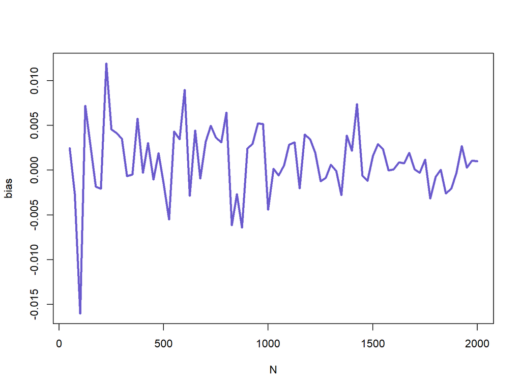

```r
IV_mean <- apply(IV, 1, mean)
bias <- IV_mean - 3.5 #ACE for compliers

plot(N, bias, type="l", col="slateblue", lwd=3)
```

- What is the problem that IV is trying to solve?
- How does it offer to solve it?
- What is IV in the potential outcomes framework? The regression framework?
- What do we need for IV to produce consistent estimates? (What is consistency vs unbiasedness?)

What are the main assumptions of IV in the regression framework?

- Model: $Y_{i} = \beta X_{i} + \epsilon_{i}$
- Exclusion restriction vs. independence